# PQuestion 6: Portfolio Constructiont

Vincent Reinshagen

November 2024

The graph highlights the cumulative returns of a balanced index fund, showcasing its growth over time under a disciplined investment strategy that incorporates various limitations to manage risk and ensure diversification. Key features of this strategy include:

- Excluding assets with less than 3 years of return data to minimize the uncertainty associated with insufficient historical performance records.
- Implementing a quarterly rebalancing mechanism to maintain the desired allocation and capitalize on market fluctuations without excessive turnover.
- Capping exposure to bonds and credit instruments at 25% to avoid over-concentration in fixed-income securities while retaining some stability in the portfolio.
- Restricting exposure to equities at 60%, balancing growth potential with risk control to prevent overexposure to the volatility of equity markets.
- Limiting the exposure to any single asset to 40%, ensuring no single asset significantly impacts the overall performance and maintaining a high degree of diversification.

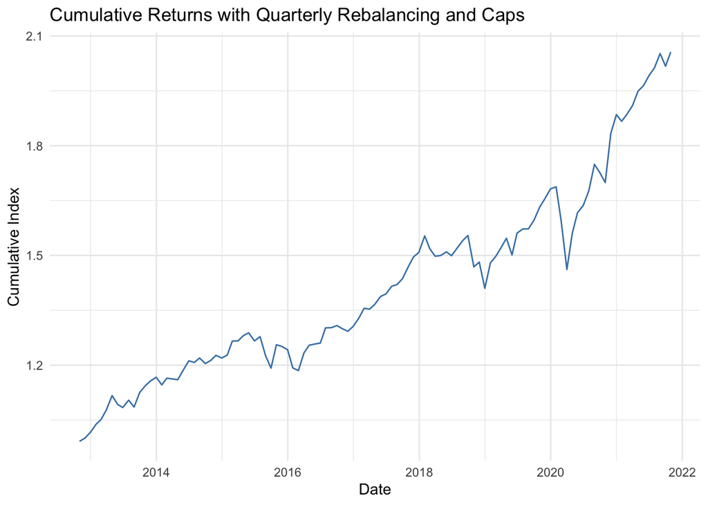